# 5. Multilevel analysis

# Review

- Multilevel models can describe the dependence between observations with hierarchical structure
- Provide unbiased estimates for the standard error for correct inference (e.g., age is insignificant after accounting for hospital effect)
- Can use fixed or random effects for the group-level effects
- Selection of models and testing of parameters can be carried out using likelihood ratio test

# Real-life example

- Home-based Hospice Care reduced end-of-life expenditure in Taiwan by Chen et. al, Medicine 2015
  - Objective: to examine the impact of home-based hospisc care on end-of-life medical expenditure
  - Subject: 78,613 cancer decedents in Taiwan
  - HLM used to account for potential clustering effect by **hospitals**
    - Result: Home-based hospice care associated with a lower EOF medical expenditure
    - Lower hospital spending index associates with less effect of home-based hospice care (tho it is just ‘nuisance’ parameters coz the researchers not interested in the effect)

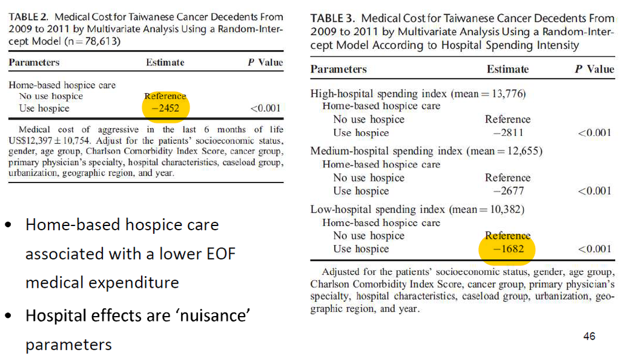